# lab-02-plastic-waste

Kipras Varkala

1/31/2022

## Load packages and data

```r
library(tidyverse)
```

```r
plastic_waste <- read.csv(here::here("data/plastic-waste.csv"))

head(plastic_waste)
```

```
##   code         entity continent year gdp_per_cap plastic_waste_per_cap
## 1  AFG    Afghanistan      Asia 2010    1614.255                    NA
## 2  ALB        Albania    Europe 2010    9927.182                 0.069
## 3  DZA        Algeria    Africa 2010   12870.603                 0.144
## 4  ASM American Samoa   Oceania 2010          NA                    NA
## 5  AND        Andorra    Europe 2010          NA                    NA
## 6  AGO         Angola    Africa 2010    5897.683                 0.062
##   mismanaged_plastic_waste_per_cap mismanaged_plastic_waste coastal_pop
## 1                               NA                       NA          NA
## 2                            0.032                    29705     2530533
## 3                            0.086                   520555    16556580
## 4                               NA                       NA          NA
## 5                               NA                       NA          NA
## 6                            0.045                    62528     3790041
##   total_pop
## 1  31411743
## 2   3204284
## 3  35468208
## 4     68420
## 5     84864
## 6  19081912
```

```r
dplyr::glimpse(plastic_waste)
```

```
## Rows: 240
## Columns: 10
## $ code                             <chr> "AFG", "ALB", "DZA", "ASM", "AND", "A~
## $ entity                           <chr> "Afghanistan", "Albania", "Algeria", ~
## $ continent                        <chr> "Asia", "Europe", "Africa", "Oceania"~
## $ year                             <int> 2010, 2010, 2010, 2010, 2010, 2010, 2~
## $ gdp_per_cap                      <dbl> 1614.255, 9927.182, 12870.603, NA, NA~
## $ plastic_waste_per_cap            <dbl> NA, 0.069, 0.144, NA, NA, 0.062, 0.25~
## $ mismanaged_plastic_waste_per_cap <dbl> NA, 0.032, 0.086, NA, NA, 0.045, 0.01~
## $ mismanaged_plastic_waste         <int> NA, 29705, 520555, NA, NA, 62528, 52,~
## $ coastal_pop                      <int> NA, 2530533, 16556580, NA, NA, 379004~
## $ total_pop                        <int> 31411743, 3204284, 35468208, 68420, 8~
```

## Exercises

### Exercise 1

We can see that most continents average around 0-1 plastic waste per capita. The only outlier is in North America in Trinidad and Tobago. A quick search shows that this one of the top 10 countries in the world producing [plastic waste](https://www.guardian.co.tt/news/forbes-tt-biggest-culprit-for-plastic-waste-per-capita-6.2.940861.820ca7f9ff)!

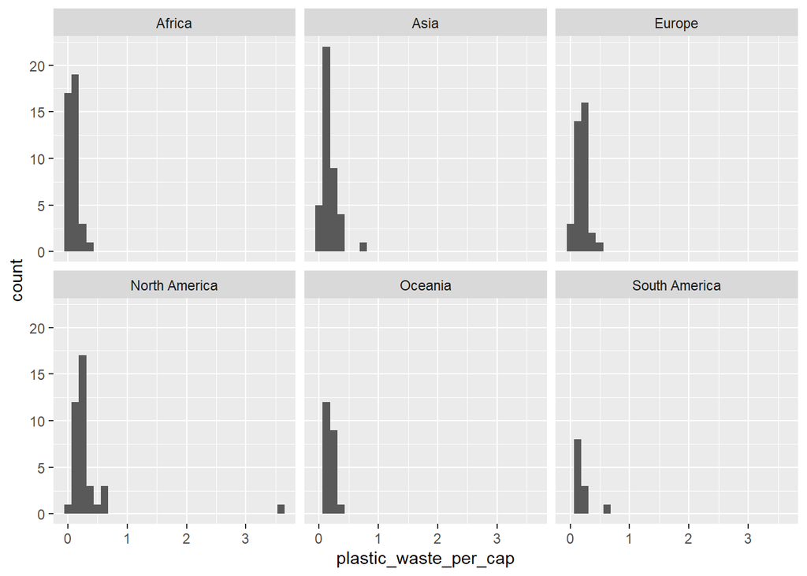

```r
ggplot(plastic_waste) +
  aes(x = plastic_waste_per_cap) +
  facet_wrap(~continent) +
  geom_histogram()
```

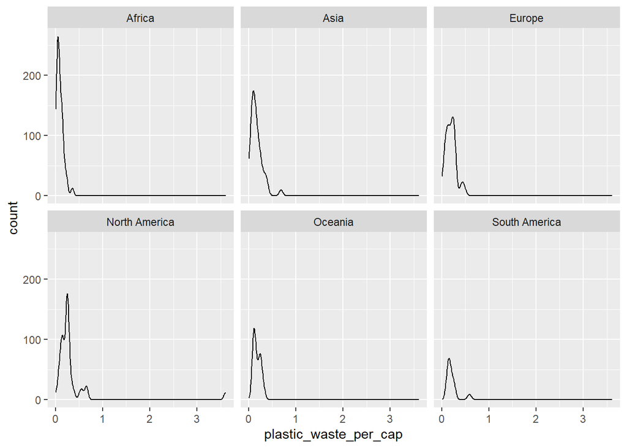

```r
ggplot(plastic_waste) +
  aes(x = plastic_waste_per_cap) +
  facet_wrap(~continent) +
  geom_density(aes(y = after_stat(count)))
```

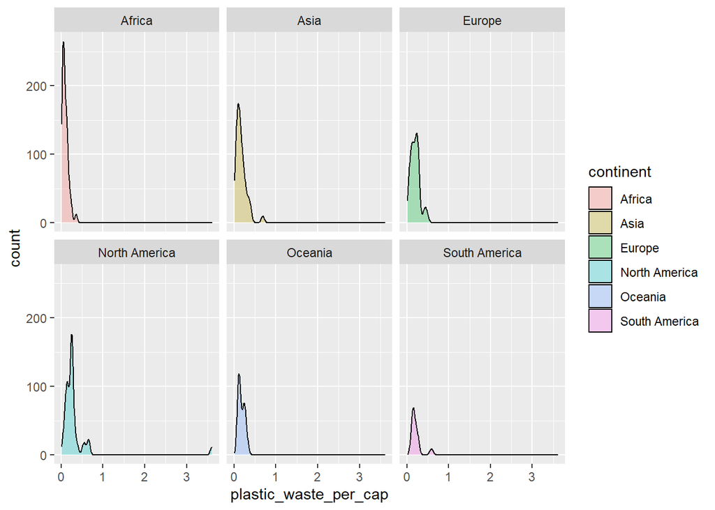

```r
ggplot(plastic_waste) +
  aes(x = plastic_waste_per_cap,
      fill = continent) +
  facet_wrap(~continent) +
  geom_density(aes(y = after_stat(count)),
               alpha = .3)
```

We define color and fill in aes() because they configure our plot globally while the alpha function only needs to apply to the geom.

### Exercise 2

The density and data points help visualize how the data is distributed by country. We are able to identify which direction the distributions are skewed and whether they are unimodal, bimodal, or multimodal.

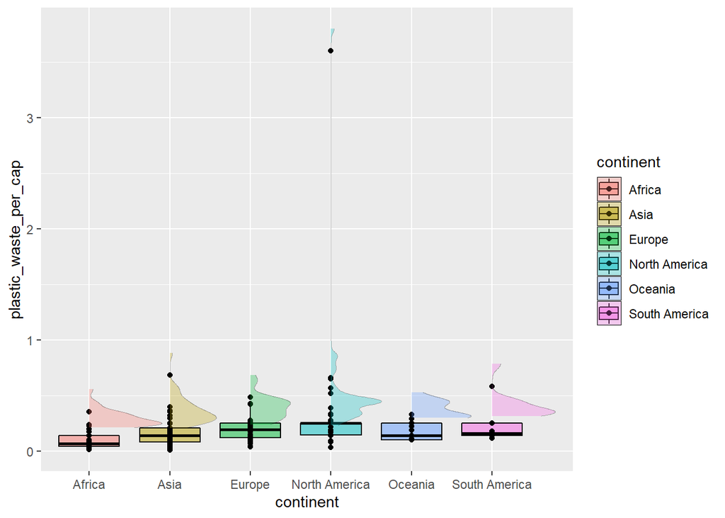

```r
ggplot(plastic_waste) +
  aes(x = continent,
      y = plastic_waste_per_cap,
      fill = continent) +
  geom_boxplot(color = "black",
               alpha = .5) +
  geom_point() +
  ggdist::stat_slab(height = 0,
                    color = "black",
                    size = 0.3,
                    alpha = .3,
                    position = position_nudge(y = .2))
```

### Exercise 3

There does not appear to be a clear distinction between plastic waste per capita and mismanaged plastic waste per capita with the exception of Africa which appears to have a rather strong positive linear trend.

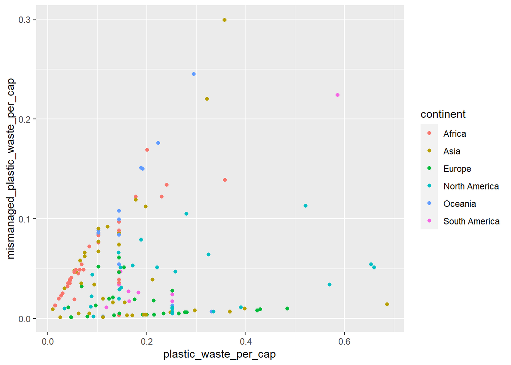

```r
plastic_waste %>% filter(plastic_waste_per_cap < 3.5) %>%
ggplot() +
  aes(x = plastic_waste_per_cap,
      y = mismanaged_plastic_waste_per_cap,
      fill = continent,
      color = continent) +
  geom_point()
```

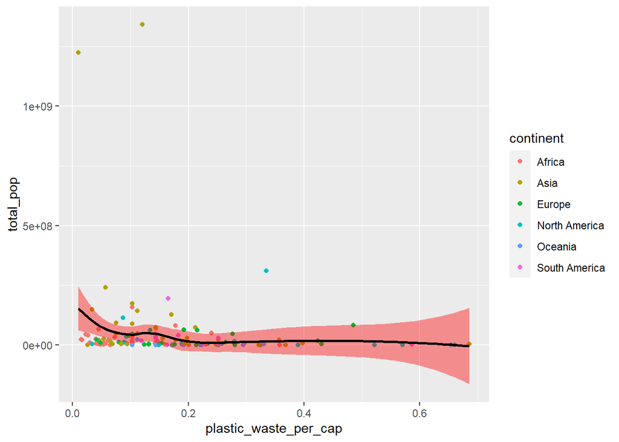

```r
plastic_waste %>% filter(plastic_waste_per_cap < 3.5) %>%
ggplot() +
  aes(x = plastic_waste_per_cap,
      y = total_pop,
      fill = continent,
      color = continent) +
  geom_point() +
  geom_smooth(
      color = "black",
      fill = "red")
```

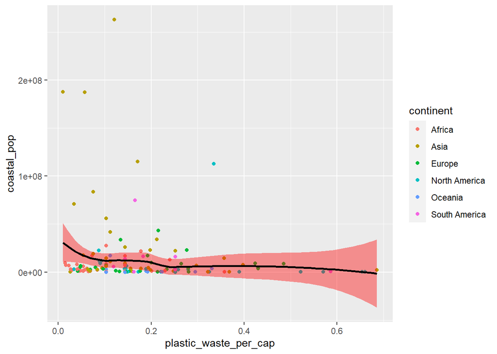

```r
plastic_waste %>% filter(plastic_waste_per_cap < 3.5) %>%
ggplot() +
  aes(x = plastic_waste_per_cap,
      y = coastal_pop,
      fill = continent,
      color = continent) +
  geom_point() +
  geom_smooth(
      color = "black",
      fill = "red")
```

Using loess smooth to visualize the trends, it does not appear that either of the plots show a stronger association than the other. There does not seem to be any relationship between plastic waste per capita and total population or coastal population.

### Buh Buh Buh Bonus!

When we factor in the proportion of coastal population to total population, we see that there is a a positive relationship between plastic waste per capita and coastal population proportion up until about 0.2 plastic waste per capita and a coastal population proportion of 0.7 where the relationship levels off. These results suggest that the greater the coastal population, plastic waste per capita also increases to a certain point. Once the proportion of coastal-to-total population is at about 0.7, then having more people living on the coast is not associated with more plastic waste per capita.

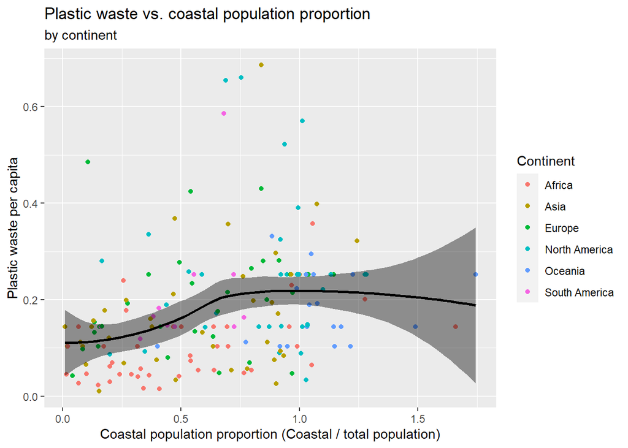

```r
plastic_waste_2 <- plastic_waste %>% filter(plastic_waste_per_cap < 3.5) %>%
  mutate(
  coast_over_total = coastal_pop/total_pop
)
ggplot(plastic_waste_2) +
  aes(x = coast_over_total,
      y = plastic_waste_per_cap,
      color = continent) +
  geom_point() +
    geom_smooth(color = "black",
              fill = "black") +
  ggtitle("Plastic waste vs. coastal population proportion") +
  labs(
              x="Coastal population proportion (Coastal / total population)",
              y="Plastic waste per capita",
              title="Plastic waste vs. coastal population proportion",
              subtitle="by continent",
              color = "Continent")
```

## Pro-Tips

### Excercise 3

Try this :D

```
ggplot(data = plastic_waste,
       mapping = aes(x = continent,
                     y = plastic_waste_per_cap)) +
  geom_violin()+
  geom_boxplot(width=.3, fill="green") +
  stat_summary(fun.y=median, geom="point")
```

### Exercise 5

Helpful reference:http://www.sthda.com/english/wiki/ggplot2-themes-and-background-colors-the-3-elements